# Introduction

This lecture goes over three different models of the labor market, each of which has a different explanation for the phenomenon of unemployment: the Neoclassical model, the Keynesian model, the Bathtub model. In this lecture, we examine each of them in turn.

# The Neoclassical Model

## Assumptions

Neoclassical economic theory is fundamentally based on the laws of supply and demand. In this theory, labor is treated as another good, which enters negatively in the utility function of workers because people would rather not work (therefore, labor is a “bad” rather than a “good”). Labor is also a useful input into production, which allows firms to sell consumption goods to workers. In the neoclassical theory, the real wage is determined at the intersection of supply and demand.

**Labor Demand.** Firms hire labor at price $w$, and sell the consumption good a price $p$. Assume that the production function is decreasing returns to scale with respect to labor (think for example, that the quantity of capital is fixed):
$$y = f(l).$$
Then, firms maximize their profits, and therefore solve:
$$\max_l \quad pf(l) - wl.$$

**Labor Supply.** Neoclassical theory of labor supply starts from a static problem of a consumer-worker choosing how much to work, and how much to consume. For example, assume that utility is strictly increasing in consumption, and strictly decreasing in the amount of labor supplied:
$$U(c, l)=u(c)-v(l),$$
so that the consumer-worker likes to consume, but does not like working. If the price of consumption is $p$, and assuming a static problem, the budget constraint of a worker/consumer is given by:
$$pc = wl.$$
You may think of $w$ as the hourly wage, for example $15$$/hour. Then $l$ would be expressed in terms of the number of hours.

*Warning*. Labor Supply and Labor Demand are sometimes being mixed up. In the language of microeconomics, workers supply labor, and firms demand labor. What workers do demand is jobs, or job vacancies, which are supplied by firms.

## Solution

**Labor Demand.** The problem of labor demand shown above leads to the following first-order condition:
$$pf'(l)-w = 0 \quad \Rightarrow \quad f'(l)=\frac{w}{p}.$$
This equation has a straightforward interpretation: at the optimum, the marginal product of labor - that is, how much is gained from using one more unit of labor in production $f'(l)$ - needs to be equal to how much that additional unit of labor costs to the firm, the real wage $w/p$. Keynes (1936) calls it the first fundamental postulate of classical economics in Chapter 2 of the [General Theory](http://cas2.umkc.edu/economics/people/facultypages/kregel/courses/econ645/winter2011/generaltheory.pdf).

**Labor Supply.** On the other hand, the problem of the consumer consists in maximizing utility under his budget constraint:
$$\begin{aligned}
\max_{c,l}& \quad u(c)-v(l),\\
&\text{s.t.}\quad p \cdot c = w \cdot l.
\end{aligned}$$

Again, similarly to the two-period optimization problem of Lecture 3, you may solve this optimization in four different ways:

1. You may compute the ratio of marginal utilities (the marginal rate of substitution between consumption and labor) and state that it is equal to minus the real wage (because labor slackens the intertemporal budget constraint, and it appears on the right hand-side of the equal sign):
   $$\frac{\partial U / \partial l}{\partial U / \partial c} = -\frac{w}{p} \quad\Rightarrow\quad\frac{v'(l)}{u'(c)}=\frac{w}{p}$$
2. You may apply the following intuitive economic argument. The marginal disutility from supplying one more unit of labor is $v'(l)$, for a worker already supplying $l$ units of them. The marginal utility which is gained from doing so is given by the number of additional units of consumption one gets out of it, given by the real wage $w/p$, and by how much I value each one of these additional utilities of consumption is valued, given by marginal utility $u'(c)$. The total gain in utility from consumption is the unit value $u'(c)$ times the number of units $w/p$, which gives the result:
   $$v'(l)=\frac{w}{p}u'(c)\quad \Rightarrow \quad \frac{v'(l)}{u'(c)}=\frac{w}{p}.$$
   Keynes (1936), who did not write one equation in his General Theory, calls this the second postulate of the classical economics, in Chapter 2: “The utility of the wage when a given volume of labour is employed is equal to the marginal disutility of that amount of employment.”
3. You may substitute out $l$ from the budget constraint, and optimize over the choice of consumption:
   $$\max_c \quad u(c)-v\left(\frac{p}{w} c\right).$$
   This implies:
   $$u'(c)-\frac{p}{w}v'(l)=0 \quad \Rightarrow \quad \frac{v'(l)}{u'(c)}=\frac{w}{p}.$$
4. You may substitute out $c$ from the budget constraint, and optimize over the choice of labor:
   $$\max_l \quad u\left(\frac{w}{p}l\right)-v(l).$$
   This implies:
   $$\frac{w}{l}u'(c)-v'(l)=0 \quad \Rightarrow \quad \frac{v'(l)}{u'(c)}=\frac{w}{p}.$$

## A Simple Example

**Assumptions.** Assume a Cobb-Douglas production function for $f(l)$, such that:
$$f(l)=Al^{1-\alpha}.$$
In the background, you can really think that the capital stock is exogenous and taken to be equal to $K=1$, which would lead to this production function exactly.

Let us also assume linear utility for consumption (that is, people enjoy increasing utility equally, regardless of whether it is coming from the first dollar or the last one - this assumption is not realistic and is really made for simplicity), as well as a power function of disutility for work:
$$u(c)=c, \quad v(l)=B\frac{l^{1+\epsilon}}{1+\epsilon}$$
so that:
$$U(c, l)=c-B\frac{l^{1+\epsilon}}{1+\epsilon},$$

**Results.** Using the above functional forms for $u(.)$ and $v(.)$ allows to write:
$$v'(l)=Bl^{\epsilon}, \quad u'(c)=1, \quad \Rightarrow \quad Bl^{\epsilon} = \frac{w}{p}.$$
Labor supply $L^{s}(.)$ as a function of the real wage $w/p$ is thus given by:
$$l =\frac{1}{B^{1/\epsilon}} \left(\frac{w}{p}\right)^{1/\epsilon} \equiv L^s\left(\frac{w}{p}\right).$$
Moreover, using the above functional form for $f(.)$ allows to write:
$$f'(l) =A(1-\alpha)l^{-\alpha} \quad \Rightarrow \quad A(1-\alpha)l^{-\alpha}=\frac{w}{p}.$$
Therefore, labor demand $L^d(.)$ is given as a function of the real wage $w/p$ by:
$$l=A^{1/\alpha}(1-\alpha)^{1/\alpha}\left(\frac{w}{p}\right)^{-1/\alpha}\equiv L^d\left(\frac{w}{p}\right).$$
To sum up, the neoclassical labor makret is composed of the following labor supply and labor demand equations:
$$\begin{aligned}
L^d\left(\frac{w}{p}\right) &= A^{1/\alpha}(1-\alpha)^{1/\alpha}\left(\frac{w}{p}\right)^{-1/\alpha},\\
L^s\left(\frac{w}{p}\right) &= \frac{1}{B^{1/\epsilon}} \left(\frac{w}{p}\right)^{1/\epsilon}.
\end{aligned}$$
Market clearing implies that labor supply equals labor demand:
$$\begin{aligned}
&L^d\left(\frac{w}{p}\right) = L^s\left(\frac{w}{p}\right) \\
&\quad \Rightarrow \quad A^{1/\alpha}(1-\alpha)^{1/\alpha}\left(\frac{w}{p}\right)^{-1/\alpha} = \frac{1}{B^{1/\epsilon}} \left(\frac{w}{p}\right)^{1/\epsilon} \\
&\quad \Rightarrow \quad \left(\frac{w}{p}\right)^{\frac{1}{\alpha} +\frac{1}{\epsilon}}= (1-\alpha)^{1/\alpha}A^{1/\alpha} B^{1/\epsilon}\\
& \quad \Rightarrow \quad \frac{w}{p} = (1-\alpha)^{\frac{\epsilon}{\alpha+\epsilon}}A^{\frac{\epsilon}{\alpha+\epsilon}} B^{\frac{\alpha}{\alpha+\epsilon}}.
\end{aligned}$$

# The “Keynesian” Model

There are two ways in which the neoclassical model above is not satisfying. Empirically, the real wage moves very little during recessions, compared to the increase in unemployment, an observation which is usually viewed as inconsistent with the neoclassical model. Moreover, and probably more importantly, the neoclassical model assumes that all unemployment is voluntary. In contrast, intuitively, the level of employment appears “too low” during recessions, in the sense that many people seem to be looking for work, but do not find one.

One potential explanation might be that wages are sticky (at least downwards). In that case, the graph shows that following a shock to labor demand, labor demand might be lower than labor supply: there is involuntary unemployment, in the sense that some workers want to work more than they do at the prevailing market wage. Workers are said to be “off their labor supply curve”, because it is the level of the demand for labor that determines the employment level.

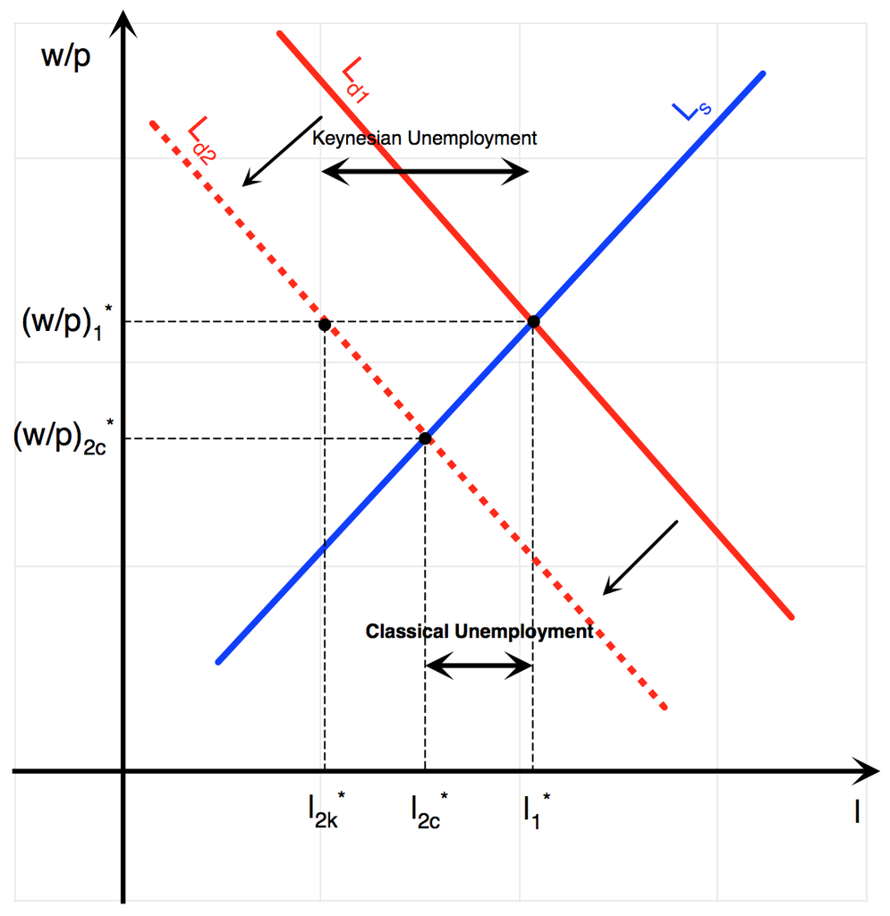

The graph shows clearly that “Keynesian” unemployment is larger than Classical Unemployment: employment falls by more than if wages were flexible.

Finally, I use quotes for “Keynesian” because although John Maynard Keynes mentioned sticky wages in *The General Theory of Employment, Interest and Money* as a potential cause for unemployment (Keynes (1936)), his thought was much more complex, and he did not see a reduction in real wages as a cure for unemployment. Although rigid wages have become synonymous with Keynes’ thought in many textbooks, you should keep in mind that John Maynard Keynes’ thought was much more complex than this, and that J.M. Keynes actually was not in favor of a reduction in wages to cure unemployment problems (you can see for yourself directly in [The General Theory](http://cas2.umkc.edu/economics/people/facultypages/kregel/courses/econ645/winter2011/generaltheory.pdf)). If you want to know more, *The Economist* has a great briefing on the [natural rate of unemployment](https://www.economist.com/economics-brief/2017/08/26/the-natural-rate-of-unemployment) - however, we will not investigate these notions any further, so you are not responsible for the content of this article.

# The Bathtub Model

A final view of unemployment consists in a mechanical, almost statistical model of the labor market, called the “bathtub” model of unemployment. This view recognizes that the labor market involves constant churning, which implies that there always are some workers who are in between jobs. It is called the bathtub model of unemployment because in some ways, the unemployment rate is quite similar to the height of the water in a bathtub.

## Model

In the bathtub model of unemployment, there is a number $L$ of people in the labor force. Jobs separate at a rate $s$, often called the **job separation rate**, and the rate at which unemployed people find new jobs is $f$, the **job finding rate**. For example, assuming that in a typical month, 20% of the unemployed find new jobs, then $f=20$%. If, on the other hand, 1% of the employed lose their jobs, then $s=1$%. Finally, the number of people unemployed is denoted by $U_{t}$ and the number of people employed as $E_{t}$. The law of motion for the unemployment population is given by:
$$\Delta U_{t+1}=sE_{t}-fU_{t}.$$

## Solution

Using the fact that people are either employed or unemployed:
$$E_{t}+U_{t}=L,$$
and plugging in the law of motion for $U_t$:
$$\begin{aligned}
\Delta U_{t+1}&=U_{t+1}-U_t=s\left(L-U_t\right)-fU_t\\
& \Rightarrow \quad U_{t+1}=(1-s-f)U_t+sL.
\end{aligned}$$
In the long run, we have that, the number of unemployed people $U^{*}$ satisfies the following equation:
$$U_{t+1}=U_{t}=U^{*}\quad\Rightarrow\quad U^{*}=\frac{sL}{s+f}.$$

The corresponding long run unemployment rate $u^{*}$, that is the number of unemployed as a function of the total population, is then given by:
$$u^{*}=\frac{U^{*}}{L}=\frac{s}{f+s}.$$

**Numerical Application.** Using the above numerical values, a job separation rate of about $s=1$%, as well as a job finding rate of about $f=20$%, we get a value for long-run unemployment, sometimes called the natural rate of unemployment, equal to:
$$u^{*}=\frac{0.01}{0.2 + 0.01}\approx 4.8\%$$
.

**Transition dynamics.** Unlike with the Solow growth model of lecture 2, we can do more and ask how the unemployment rate converges to this steady-state level, using the law of motion for unemployment (this was impossible for the Solow growth model because the law of motion for capital was too complex):

$$\begin{aligned}
U_{t+1}&=\left(1-s-f\right)U_{t}+sL\\
& \quad\Rightarrow\quad U_{t+1}-U^{*}=\left(1-s-f\right)\left(U_{t}-U^{*}\right)\\
& \quad\Rightarrow\quad U_{t}=U^{*}+\left(1-s-f\right)^{t}\left(U_{0}-U^{*}\right).
\end{aligned}$$

## Data on Job Churning

Data on job churning is collected by the Bureau of Labor Statistics (the Job Opening and Labor Turnover Survey, also known as JOLTS). You may in particular view the latest data on [Job openings](https://www.bls.gov/news.release/jolts.t01.htm), [Hires levels](https://www.bls.gov/news.release/jolts.t02.htm), [Total separations](https://www.bls.gov/news.release/jolts.t03.htm), [Quits](https://www.bls.gov/news.release/jolts.t04.htm), [Layoffs and discharges](https://www.bls.gov/news.release/jolts.t05.htm).

The evolution of job openings and hire levels on the one hand, and total separations, quits, layoffs and discharges are plotted on the two figures below.

This data shows that there are many ways in which the bathtub model of unemployment is an oversimplification. First, the separation and job finding rates both fall substantially during recessions. Second, the notion of a “separation” is a bit more subtle in the real world: some separations are chosen from workers (quits), some of them are chosen by firms (layoffs). Third, the job finding rate is also endogenous, because not all job openings lead to hires.

Increased unemployment during recessions is explained by an increase in layoffs, but more importantly by a decline in job openings.

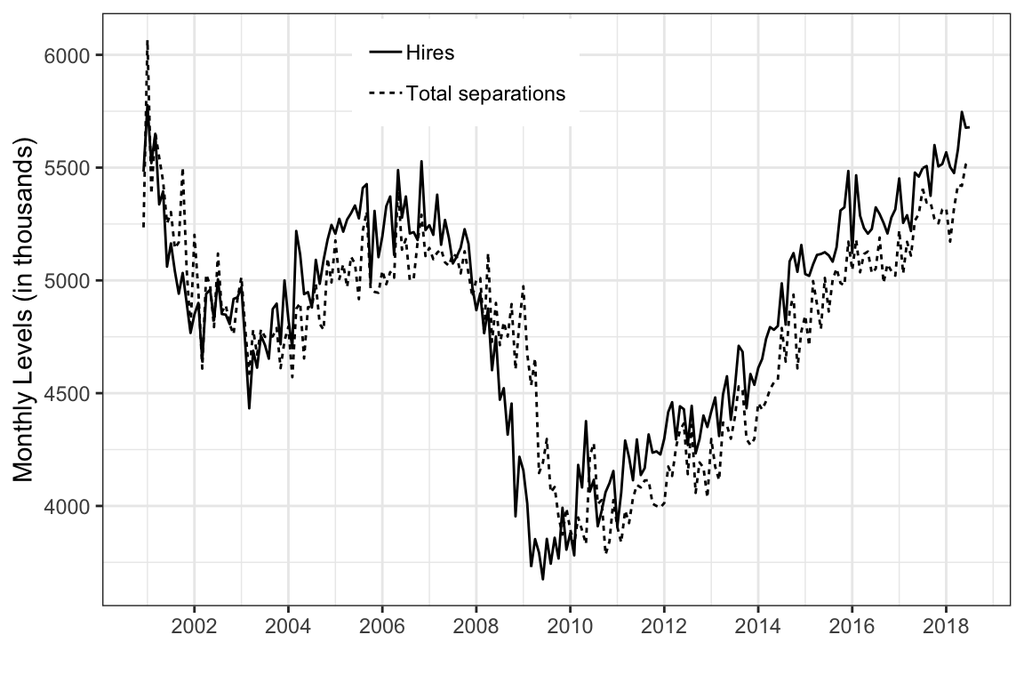

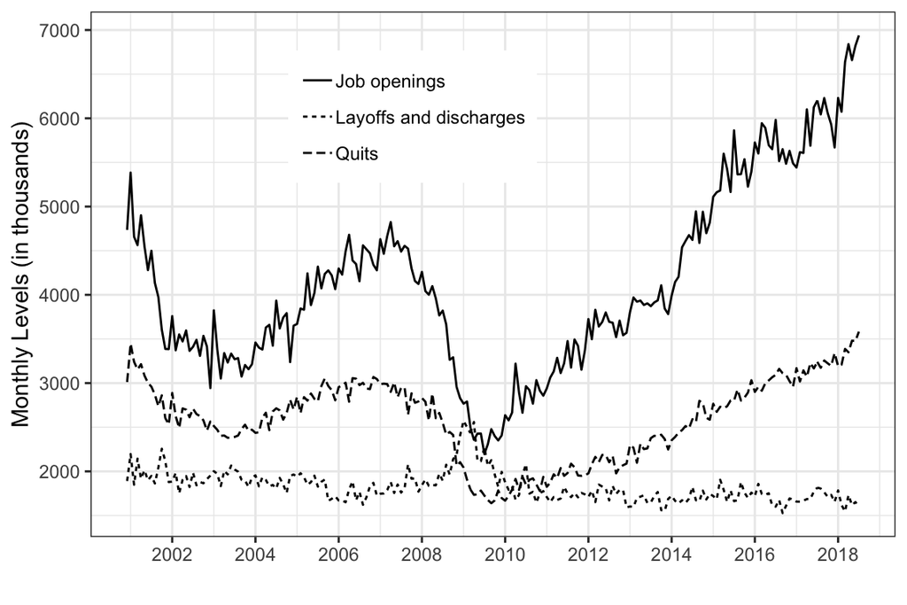

# Readings - To go further

[Several quotes in search of a theory, The Economist, January 17, 2011.](https://www.economist.com/free-exchange/2011/01/17/several-quotes-in-search-of-a-theory)

[Blanchard Olivier, and Wolfers Justin. “The Role of Shocks and Institutions in the Rise of European Unemployment: The Aggregate Evidence.” The Economic Journal 110, no. 462 (December 25, 2001): 1–33.](https://doi.org/10.1111/1468-0297.00518)

[What We Know About the 92 Million Americans Who Aren’t in the Labor Force, Wall Street Journal, Oct 21, 2015.](https://blogs.wsj.com/economics/2015/10/21/what-we-know-about-the-92-million-americans-who-arent-in-the-labor-force/)

(Gated) [“Central bankers’ holy grail: The Natural rate of unemployment”, *The Economist*, August 26, 2017.](https://www.economist.com/economics-brief/2017/08/26/the-natural-rate-of-unemployment)

Keynes, John Maynard. 1936. *The General Theory of Employment, Interest, and Money*.